# Metro Melbourne COVID-19 2023 survey; Census 2016 & 2021 residential relocation

Data analysis

Dr James Reynolds, Public Transport Research Group (PTRG), Monash University

2023-02-01

# 1.0 Introduction

As part of the work program for the upcoming Metro Melbourne COVID-19 2023 (second) survey PTRG is comparing the usual place of residence results from the 2016 and 2021 Australian census. The analysis includes looking at Metro Melbourne as a whole, and also the inner, middle and outer regions individually, as well as the Peri-Urban Area and Rest of Victoria regions that will be used for the forthcoming Regional Victoria COVID-19 2023 survey.

With those regions being as defined in the 2020 (first) survey.

This work note summarises the analysis and findings. The next section discusses the datasets retrieved from the Australian Bureau of Statistics (ABS) Table Builder. Section 3 shows the regions used in the 2020 (first) survey and this analysis. Section 4 presents the analysis results.

# 2.0 Data

Sixteen datasets were extracted as Comma-Separated Values (CSV) files using the ABS Table Builder online system. The first eight datasets were the results for Victorian residents by Local Government Area for the questions about usual place of residence 1 year ago and 5 years ago, with data retrieved for the 2016 and 2021 censuses. Separate tables were extracted for respondents who answered that their previous place of residence was within a specific Victorian LGA, and for those whose previous place of residence was in another state or territory. Examples from the data tables are shown below in Tables 1 and 2.

Specifically the Place of Usual Residence one year ago (PUR1P) and Place of Usual Residence five years ago (PUR5P) variables. Details are avaiable at https://www.abs.gov.au/census/guide-census-data/census-dictionary/2021/variables-topic/location/place-usual-residence-one-year-ago-pur1p

Some minor edits were made directly to the CSV files prior to importation into R. This includes fixing the LGA name fields, which were inconsistent. The 2016 version also showed the type of LGA, (Shire, Regional City or City) as letters (S, RC, C) in brackets. The 2021 CSV files were updated to adopt the 2016 approach.

Table 1: 2016 census, State/Territory of Usual Residence oneyear ago (PUR1P), results by LGA for Victoria, first 6 results

| LGA | New South Wales | Victoria | Queensland | South Australia | Western Australia | Tasmania | Northern Territory | Australian Capital Territory | Other Territories | Overseas |
| --- | --- | --- | --- | --- | --- | --- | --- | --- | --- | --- |
| Alpine (S) | 128 | 10,802 | 61 | 12 | 26 | 12 | 14 | 0 | 0 | 68 |
| Ararat (RC) | 26 | 9,684 | 30 | 21 | 35 | 5 | 4 | 0 | 0 | 73 |
| Ballarat (C) | 254 | 90,368 | 327 | 156 | 130 | 65 | 59 | 35 | 0 | 633 |
| Banyule (C) | 334 | 109,352 | 328 | 100 | 144 | 46 | 63 | 65 | 0 | 1,611 |
| Bass Coast (S) | 99 | 29,121 | 114 | 23 | 52 | 20 | 37 | 3 | 0 | 139 |
| Baw Baw (S) | 110 | 43,156 | 153 | 39 | 65 | 25 | 21 | 10 | 3 | 157 |

Table 2: 2016 census, LGA of Usual Residence one year ago(PUR1P), results by LGA for Victoria, first 6 results

| LGA | Alpine (S) | Ararat (RC) | Ballarat (C) | Banyule (C) | Bass Coast (S) | Baw Baw (S) | Bayside (C) | Benalla (RC) | Boroondara (C) | Brimbank (C) |
| --- | --- | --- | --- | --- | --- | --- | --- | --- | --- | --- |
| Alpine (S) | 10,359 | 0 | 0 | 3 | 0 | 6 | 8 | 3 | 14 | 0 |
| Ararat (RC) | 4 | 9,265 | 49 | 6 | 0 | 0 | 0 | 0 | 7 | 3 |
| Ballarat (C) | 4 | 109 | 85,943 | 49 | 14 | 21 | 22 | 4 | 52 | 38 |
| Banyule (C) | 12 | 5 | 26 | 102,254 | 18 | 15 | 33 | 3 | 540 | 57 |
| Bass Coast (S) | 5 | 0 | 10 | 29 | 27,123 | 52 | 14 | 3 | 39 | 14 |
| Baw Baw (S) | 0 | 0 | 16 | 16 | 60 | 40,455 | 11 | 0 | 25 | 4 |

Running total is 8+4=12 of 16

See details at https://www.abs.gov.au/census/guide-census-data/census-dictionary/2021/variables-topic/location/usual-address-one-year-ago-indicator-uai1p. As an example, the 10,359 people from Alpine Shire in 2016 whose place of usual residence was (also) within Alpine Shire one year prior to the 2016 census (from Table 2) consist of 9,711 who had not moved house (see Table 3) and 648 who had moved house, but to somewhere else within the Alpine Shire (as 10,359-9,711-648.

Table 3: 2016 census, Usual Address one year ago Indicator(UAI1P), results by LGA for Victoria, first 6 results

| LGA | Same as in 2016 | Elsewhere in Australia | Overseas in 2015 | Not stated | Not applicable |
| --- | --- | --- | --- | --- | --- |
| Alpine (S) | 9,711 | 1,351 | 68 | 1,107 | 94 |
| Ararat (RC) | 8,580 | 1,243 | 73 | 1,602 | 107 |
| Ballarat (C) | 76,451 | 15,107 | 633 | 8,217 | 1,283 |
| Banyule (C) | 97,543 | 13,051 | 1,611 | 8,129 | 1,535 |
| Bass Coast (S) | 24,722 | 4,816 | 139 | 2,831 | 303 |
| Baw Baw (S) | 37,246 | 6,417 | 157 | 4,093 | 566 |

Combining the tables (PUR1P by State and by LGA, and UAI1P) gives a single table for each census and time period. Table 4 shows an example of the combined tables.

2016 and 2021 census; 1 year ago and 5 years ago

Table 4: 2016 census, place of usual residence 1 year agocombined table,first 6 results for first 8 columns

| LGA | Same as in 2016 | Overseas in 2015 | Not stated | Not applicable | Alpine (S) | Ararat (RC) | Ballarat (C) |
| --- | --- | --- | --- | --- | --- | --- | --- |
| Alpine (S) | 9,711 | 68 | 1,107 | 94 | 648 | 0 | 0 |
| Ararat (RC) | 8,580 | 73 | 1,602 | 107 | 4 | 685 | 49 |
| Ballarat (C) | 76,451 | 633 | 8,217 | 1,283 | 4 | 109 | 9,492 |
| Banyule (C) | 97,543 | 1,611 | 8,129 | 1,535 | 12 | 5 | 26 |
| Bass Coast (S) | 24,722 | 139 | 2,831 | 303 | 5 | 0 | 10 |
| Baw Baw (S) | 37,246 | 157 | 4,093 | 566 | 0 | 0 | 16 |

Finally, four more datasets were extracted for states and territories that are not Victoria for people moving from Victorian LGAs one and five years before each of the 2016 and 2021 censuses. These datasets a needed to be able to calculate the regions that people resident in Victorian LGAS in 2011, 2015, 2016 and 2021 moved to, allowing analysis of residential relocation from the inner, middle, outer, peri-urban and rest of Victoria regions.

8+4+4=16

The rest of Australia, being New South Wales, Queensland etc.

Note, that it is not possible to include analysis of people who moved from Victorian LGAs to places overseas, as these people are not in the census data. But, at least this analysis can consider residential relocation FROM our regions of interest TO other places in (all of) Australia.

Table 5: 2016 census, LGA of residence one year before censusfor those who moved to Victoria, results by State and Territory fornon-Victorian locations, first 6 results and first 6 LGAs

| Location | Alpine (S) | Ararat (RC) | Ballarat (C) | Banyule (C) | Bass Coast (S) |
| --- | --- | --- | --- | --- | --- |
| New South Wales | 89 | 15 | 229 | 288 | 93 |
| Queensland | 47 | 28 | 337 | 312 | 102 |
| South Australia | 6 | 14 | 86 | 83 | 28 |
| Tasmania | 5 | 12 | 36 | 45 | 17 |
| Western Australia | 15 | 11 | 83 | 100 | 35 |
| Northern Territory | 4 | 3 | 50 | 67 | 24 |

# 3.0 Regions

Inner, middle and outer regions were defined in the 2020 Melbourne COVID-19 survey, as shown in Table 6. The additional zones of Peri-Urban Area and Rest of Victoria have been defined in the work to date for the forthcoming Regional Victoria COVID-19 survey, and Table 6 also shows allocation of LGAs to those zones as well.

Note that the Peri-Urban Area and Rest of Victoria zones have actually been defined using the Statistical Area 3 (SA3) boundaries. These are slightly different to LGA boundaries, so LGAs have been assigned to one of the Peri-Urban Area and Rest of Victoria regions by inspection.

Table 6: Victorian LGAs by region, first 15 entries

| LGA | Region |
| --- | --- |
| Alpine (S) | Rest of Victoria |
| Ararat (RC) | Rest of Victoria |
| Ballarat (C) | Peri-Urban Area |
| Banyule (C) | Middle |
| Bass Coast (S) | Peri-Urban Area |
| Baw Baw (S) | Peri-Urban Area |
| Bayside (C) | Middle |
| Benalla (RC) | Rest of Victoria |
| Boroondara (C) | Middle |
| Brimbank (C) | Middle |
| Buloke (S) | Rest of Victoria |
| Campaspe (S) | Rest of Victoria |
| Cardinia (S) | Outer |
| Casey (C) | Outer |
| Central Goldfields (S) | Peri-Urban Area |

# 4.0 Results

The raw data from the ABS table builder (Table 4) and the allocation of LGAs to each region (Table 6) have been combined. This results in tables of usual address 1 or 5 years ago, by region. Results are summarised in Tables 7-10.

Note, the ‘not stated’ and ‘not applicable’ fields have been dropped.

Table 7: 2016 census, Usual address one year ago, byregion

| Region | Same as in 2016 | Inner | Middle | Outer | Peri-Urban Area | Rest of Victoria | New South Wales | Queensland | South Australia | Western Australia | Tasmania | Northern Territory | Australian Capital Territory | Other Territories | Overseas in 2015 | Total |
| --- | --- | --- | --- | --- | --- | --- | --- | --- | --- | --- | --- | --- | --- | --- | --- | --- |
| Inner | 264,649 (70.7%) | 367 (0.1%) | 4,379 (1.2%) | 23,344 (6.2%) | 6,463 (1.7%) | 35,915 (9.6%) | 3,933 (1.1%) | 2,932 (0.8%) | 1,054 (0.3%) | 1,957 (0.5%) | 534 (0.1%) | 300 (0.1%) | 705 (0.2%) | 14 (0.0%) | 27,844 (7.4%) | 374,390 (100.0%) |
| Middle | 1,605,376 (84.6%) | 1,206 (0.1%) | 33,254 (1.8%) | 15,336 (0.8%) | 53,571 (2.8%) | 114,989 (6.1%) | 6,911 (0.4%) | 5,189 (0.3%) | 2,598 (0.1%) | 3,154 (0.2%) | 1,008 (0.1%) | 719 (0.0%) | 1,155 (0.1%) | 18 (0.0%) | 53,493 (2.8%) | 1,897,977 (100.0%) |
| Outer | 1,496,836 (87.5%) | 10,166 (0.6%) | 55,710 (3.3%) | 3,649 (0.2%) | 19,768 (1.2%) | 84,288 (4.9%) | 5,716 (0.3%) | 4,262 (0.2%) | 1,782 (0.1%) | 2,144 (0.1%) | 698 (0.0%) | 641 (0.0%) | 531 (0.0%) | 12 (0.0%) | 24,902 (1.5%) | 1,711,105 (100.0%) |
| Peri-Urban Areas | 636,792 (85.8%) | 1,634 (0.2%) | 30,981 (4.2%) | 4,701 (0.6%) | 24,082 (3.2%) | 31,161 (4.2%) | 2,429 (0.3%) | 2,473 (0.3%) | 932 (0.1%) | 1,069 (0.1%) | 438 (0.1%) | 620 (0.1%) | 256 (0.0%) | 3 (0.0%) | 4,937 (0.7%) | 742,508 (100.0%) |
| Rest of Victoria | 522,054 (86.6%) | 765 (0.1%) | 9,732 (1.6%) | 17,879 (3.0%) | 16,543 (2.7%) | 22,255 (3.7%) | 4,624 (0.8%) | 2,344 (0.4%) | 1,188 (0.2%) | 1,057 (0.2%) | 334 (0.1%) | 556 (0.1%) | 246 (0.0%) | 6 (0.0%) | 3,507 (0.6%) | 603,090 (100.0%) |
| Total | 4,525,707 (84.9%) | 14,138 (0.3%) | 134,056 (2.5%) | 64,909 (1.2%) | 120,427 (2.3%) | 288,608 (5.4%) | 23,613 (0.4%) | 17,200 (0.3%) | 7,554 (0.1%) | 9,381 (0.2%) | 3,012 (0.1%) | 2,836 (0.1%) | 2,893 (0.1%) | 53 (0.0%) | 114,683 (2.2%) | 5,329,070 (100.0%) |

Table 8: 2021 census, Usual address one year ago, byregion

| Region | Same as in 2021 | Inner | Middle | Outer | Peri-Urban Area | Rest of Victoria | New South Wales | Queensland | South Australia | Western Australia | Tasmania | Northern Territory | Australian Capital Territory | Other Territories | Overseas in 2020 | Total |
| --- | --- | --- | --- | --- | --- | --- | --- | --- | --- | --- | --- | --- | --- | --- | --- | --- |
| Inner | 287,174 (69.2%) | 544 (0.1%) | 7,347 (1.8%) | 37,043 (8.9%) | 11,008 (2.7%) | 52,169 (12.6%) | 4,408 (1.1%) | 2,892 (0.7%) | 1,113 (0.3%) | 1,383 (0.3%) | 677 (0.2%) | 333 (0.1%) | 745 (0.2%) | 4 (0.0%) | 8,276 (2.0%) | 415,116 (100.0%) |
| Middle | 1,748,083 (86.0%) | 1,638 (0.1%) | 37,938 (1.9%) | 16,831 (0.8%) | 64,919 (3.2%) | 131,633 (6.5%) | 5,402 (0.3%) | 3,507 (0.2%) | 1,450 (0.1%) | 1,292 (0.1%) | 1,089 (0.1%) | 578 (0.0%) | 842 (0.0%) | 0 (0.0%) | 18,159 (0.9%) | 2,033,361 (100.0%) |
| Outer | 1,819,216 (88.7%) | 10,226 (0.5%) | 63,157 (3.1%) | 5,315 (0.3%) | 22,749 (1.1%) | 106,350 (5.2%) | 4,426 (0.2%) | 2,886 (0.1%) | 1,210 (0.1%) | 1,016 (0.0%) | 782 (0.0%) | 566 (0.0%) | 418 (0.0%) | 3 (0.0%) | 12,384 (0.6%) | 2,050,704 (100.0%) |
| Peri-Urban Areas | 751,873 (86.2%) | 1,842 (0.2%) | 38,090 (4.4%) | 5,441 (0.6%) | 27,380 (3.1%) | 38,089 (4.4%) | 2,260 (0.3%) | 1,851 (0.2%) | 711 (0.1%) | 682 (0.1%) | 531 (0.1%) | 367 (0.0%) | 261 (0.0%) | 0 (0.0%) | 3,061 (0.4%) | 872,439 (100.0%) |
| Rest of Victoria | 566,460 (87.3%) | 922 (0.1%) | 10,500 (1.6%) | 17,770 (2.7%) | 17,331 (2.7%) | 24,419 (3.8%) | 4,759 (0.7%) | 2,022 (0.3%) | 903 (0.1%) | 501 (0.1%) | 342 (0.1%) | 437 (0.1%) | 304 (0.0%) | 0 (0.0%) | 2,139 (0.3%) | 648,809 (100.0%) |
| Total | 5,172,806 (85.9%) | 15,172 (0.3%) | 157,032 (2.6%) | 82,400 (1.4%) | 143,387 (2.4%) | 352,660 (5.9%) | 21,255 (0.4%) | 13,158 (0.2%) | 5,387 (0.1%) | 4,874 (0.1%) | 3,421 (0.1%) | 2,281 (0.0%) | 2,570 (0.0%) | 7 (0.0%) | 44,019 (0.7%) | 6,020,429 (100.0%) |

Table 9: 2016 census, Usual address five years ago, byregion

| Region | Same as in 2016 | Inner | Middle | Outer | Peri-Urban Area | Rest of Victoria | New South Wales | Queensland | South Australia | Western Australia | Tasmania | Northern Territory | Australian Capital Territory | Other Territories | Overseas in 2011 | Total |
| --- | --- | --- | --- | --- | --- | --- | --- | --- | --- | --- | --- | --- | --- | --- | --- | --- |
| Inner | 133,453 (36.2%) | 1,078 (0.3%) | 10,736 (2.9%) | 26,837 (7.3%) | 13,567 (3.7%) | 71,767 (19.5%) | 9,844 (2.7%) | 7,615 (2.1%) | 2,994 (0.8%) | 4,589 (1.2%) | 1,759 (0.5%) | 633 (0.2%) | 2,058 (0.6%) | 8 (0.0%) | 81,547 (22.1%) | 368,485 (100.0%) |
| Middle | 1,091,546 (60.2%) | 3,742 (0.2%) | 76,908 (4.2%) | 29,615 (1.6%) | 117,591 (6.5%) | 252,318 (13.9%) | 18,587 (1.0%) | 14,155 (0.8%) | 6,183 (0.3%) | 7,106 (0.4%) | 3,244 (0.2%) | 1,633 (0.1%) | 3,212 (0.2%) | 53 (0.0%) | 187,345 (10.3%) | 1,813,238 (100.0%) |
| Outer | 985,787 (62.9%) | 30,537 (1.9%) | 142,917 (9.1%) | 9,195 (0.6%) | 55,750 (3.6%) | 208,678 (13.3%) | 14,064 (0.9%) | 11,460 (0.7%) | 4,447 (0.3%) | 4,730 (0.3%) | 2,192 (0.1%) | 1,534 (0.1%) | 1,424 (0.1%) | 42 (0.0%) | 95,475 (6.1%) | 1,568,232 (100.0%) |
| Peri-Urban Areas | 425,357 (60.6%) | 4,755 (0.7%) | 76,999 (11.0%) | 13,027 (1.9%) | 62,061 (8.8%) | 81,607 (11.6%) | 7,006 (1.0%) | 6,356 (0.9%) | 2,706 (0.4%) | 3,120 (0.4%) | 1,506 (0.2%) | 1,418 (0.2%) | 722 (0.1%) | 7 (0.0%) | 15,706 (2.2%) | 702,353 (100.0%) |
| Rest of Victoria | 369,309 (64.1%) | 2,547 (0.4%) | 24,516 (4.3%) | 43,030 (7.5%) | 40,441 (7.0%) | 57,839 (10.0%) | 11,736 (2.0%) | 6,711 (1.2%) | 3,408 (0.6%) | 2,726 (0.5%) | 1,103 (0.2%) | 1,364 (0.2%) | 576 (0.1%) | 3 (0.0%) | 11,040 (1.9%) | 576,349 (100.0%) |
| Total | 3,005,452 (59.8%) | 42,659 (0.8%) | 332,076 (6.6%) | 121,704 (2.4%) | 289,410 (5.8%) | 672,209 (13.4%) | 61,237 (1.2%) | 46,297 (0.9%) | 19,738 (0.4%) | 22,271 (0.4%) | 9,804 (0.2%) | 6,582 (0.1%) | 7,992 (0.2%) | 113 (0.0%) | 391,113 (7.8%) | 5,028,657 (100.0%) |

Table 10: 2021 census, Usual address five years ago, byregion

| Region | Same as in 2021 | Inner | Middle | Outer | Peri-Urban Area | Rest of Victoria | New South Wales | Queensland | South Australia | Western Australia | Tasmania | Northern Territory | Australian Capital Territory | Other Territories | Overseas in 2016 | Total |
| --- | --- | --- | --- | --- | --- | --- | --- | --- | --- | --- | --- | --- | --- | --- | --- | --- |
| Inner | 151,929 (37.6%) | 1,095 (0.3%) | 12,261 (3.0%) | 37,706 (9.3%) | 16,348 (4.1%) | 85,422 (21.2%) | 11,216 (2.8%) | 7,252 (1.8%) | 3,015 (0.7%) | 4,514 (1.1%) | 1,536 (0.4%) | 635 (0.2%) | 1,877 (0.5%) | 6 (0.0%) | 68,815 (17.0%) | 403,627 (100.0%) |
| Middle | 1,172,227 (61.0%) | 4,011 (0.2%) | 85,504 (4.5%) | 37,323 (1.9%) | 134,052 (7.0%) | 281,785 (14.7%) | 18,637 (1.0%) | 12,316 (0.6%) | 6,254 (0.3%) | 7,382 (0.4%) | 2,655 (0.1%) | 1,872 (0.1%) | 2,925 (0.2%) | 3 (0.0%) | 154,053 (8.0%) | 1,920,999 (100.0%) |
| Outer | 1,141,599 (61.7%) | 30,828 (1.7%) | 168,927 (9.1%) | 13,891 (0.8%) | 66,777 (3.6%) | 270,054 (14.6%) | 17,394 (0.9%) | 11,010 (0.6%) | 5,477 (0.3%) | 5,832 (0.3%) | 2,310 (0.1%) | 2,218 (0.1%) | 1,547 (0.1%) | 17 (0.0%) | 113,221 (6.1%) | 1,851,102 (100.0%) |
| Peri-Urban Areas | 477,371 (58.6%) | 5,993 (0.7%) | 95,281 (11.7%) | 16,147 (2.0%) | 71,817 (8.8%) | 105,242 (12.9%) | 7,979 (1.0%) | 6,129 (0.8%) | 2,652 (0.3%) | 2,597 (0.3%) | 1,497 (0.2%) | 1,564 (0.2%) | 907 (0.1%) | 4 (0.0%) | 20,121 (2.5%) | 815,301 (100.0%) |
| Rest of Victoria | 385,404 (62.6%) | 3,135 (0.5%) | 28,135 (4.6%) | 45,682 (7.4%) | 45,682 (7.4%) | 64,701 (10.5%) | 13,289 (2.2%) | 6,109 (1.0%) | 3,056 (0.5%) | 2,138 (0.3%) | 1,044 (0.2%) | 1,417 (0.2%) | 688 (0.1%) | 3 (0.0%) | 15,182 (2.5%) | 615,665 (100.0%) |
| Total | 3,328,530 (59.4%) | 45,062 (0.8%) | 390,108 (7.0%) | 150,749 (2.7%) | 334,676 (6.0%) | 807,204 (14.4%) | 68,515 (1.2%) | 42,816 (0.8%) | 20,454 (0.4%) | 22,463 (0.4%) | 9,042 (0.2%) | 7,706 (0.1%) | 7,944 (0.1%) | 33 (0.0%) | 371,392 (6.6%) | 5,606,694 (100.0%) |

Tables 7-10 have a large amount of data, which makes comparison difficult. Hence, the following sections examine various components of the usual address one and five years ago results to identify significant changes between pre- and during-COVID home relocation.

## 4.1 Residential relocation FROM Melbourne within the year before the census

### 4.1.1 FROM the inner region of Melbourne

The third columns of Tables 7-10 provide details of where people who where living in the inner region one and five years before the 2016 and 2021 had moved to in 2016 and 2021, respectively. The second column, first row of each table shows the number of people who were living in the inner region and who did not move. Table 11 collects this data.

i.e. in 2011, 2015, 2016 and 2020

Table 11: Destinations of those moving FROM the Inner region tolocations within Victoria prior to the census

| Destination | 2011-16 | 2015-16 | 2016-21 | 2020-21 |
| --- | --- | --- | --- | --- |
| Did not move | 133,453 (75.8%) | 264,649 (94.9%) | 151,929 (77.1%) | 287,174 (95.0%) |
| Inner | 1,078 (0.6%) | 367 (0.1%) | 1,095 (0.6%) | 544 (0.2%) |
| Middle | 3,742 (2.1%) | 1,206 (0.4%) | 4,011 (2.0%) | 1,638 (0.5%) |
| Outer | 30,537 (17.3%) | 10,166 (3.6%) | 30,828 (15.6%) | 10,226 (3.4%) |
| Peri-Urban Areas | 4,755 (2.7%) | 1,634 (0.6%) | 5,993 (3.0%) | 1,842 (0.6%) |
| Rest of Victoria | 2,547 (1.4%) | 765 (0.3%) | 3,135 (1.6%) | 922 (0.3%) |
| Total | 176,112 (100.0%) | 278,787 (100.0%) | 196,991 (100.0%) | 302,346 (100.0%) |

However, the ‘Rest of Australia’ data needs to be added as well, so that it is possible to see people who moved from inner to other parts of Australia. This revision is shown in Table 11.

This was imported from the ABS data above, see Table 5

Table 11: Destinations of those moving FROM the Inner region tolocations within Australia prior to the census

| Destination | 2015-16 | 2020-21 | 2011-16 | 2016-21 |
| --- | --- | --- | --- | --- |
| Did not move | 264,649 (93.4%) | 287,174 (92.7%) | 133,453 (71.3%) | 151,929 (71.3%) |
| Inner | 367 (0.1%) | 544 (0.2%) | 1,078 (0.6%) | 1,095 (0.5%) |
| Middle | 1,206 (0.4%) | 1,638 (0.5%) | 3,742 (2.0%) | 4,011 (1.9%) |
| Outer | 10,166 (3.6%) | 10,226 (3.3%) | 30,537 (16.3%) | 30,828 (14.5%) |
| Peri-Urban Areas | 1,634 (0.6%) | 1,842 (0.6%) | 4,755 (2.5%) | 5,993 (2.8%) |
| Rest of Victoria | 765 (0.3%) | 922 (0.3%) | 2,547 (1.4%) | 3,135 (1.5%) |
| New South Wales | 1,942 (0.7%) | 2,558 (0.8%) | 4,531 (2.4%) | 5,708 (2.7%) |
| Queensland | 1,115 (0.4%) | 2,393 (0.8%) | 2,609 (1.4%) | 4,813 (2.3%) |
| South Australia | 259 (0.1%) | 601 (0.2%) | 808 (0.4%) | 1,359 (0.6%) |
| Tasmania | 209 (0.1%) | 984 (0.3%) | 577 (0.3%) | 1,804 (0.8%) |
| Western Australia | 525 (0.2%) | 385 (0.1%) | 1,649 (0.9%) | 1,160 (0.5%) |
| Northern Territory | 127 (0.0%) | 211 (0.1%) | 309 (0.2%) | 403 (0.2%) |
| Australian Capital Territory | 241 (0.1%) | 369 (0.1%) | 613 (0.3%) | 909 (0.4%) |
| Other Territories | 3 (0.0%) | 0 (0.0%) | 0 (0.0%) | 4 (0.0%) |
| Total | 283,208 (100.0%) | 309,847 (100.0%) | 187,208 (100.0%) | 213,151 (100.0%) |

Figure 1 and Table 12 compare the proportion those who were inner residents one year prior to each census who moved within Australia in the year before each census.

People who moved overseas are not included as they are not present in the census data

Table 12: Inner residents one year prior to the census,residential relocation in the year prior to the census, bycensus

| Destination | 2015-16 | 2020-21 |
| --- | --- | --- |
| Did not move | 264,649 (93.4%) | 287,174 (92.7%) |
| Moved | 18,559 (6.6%) | 22,673 (7.3%) |
| Total | 283,208 (100.0%) | 309,847 (100.0%) |

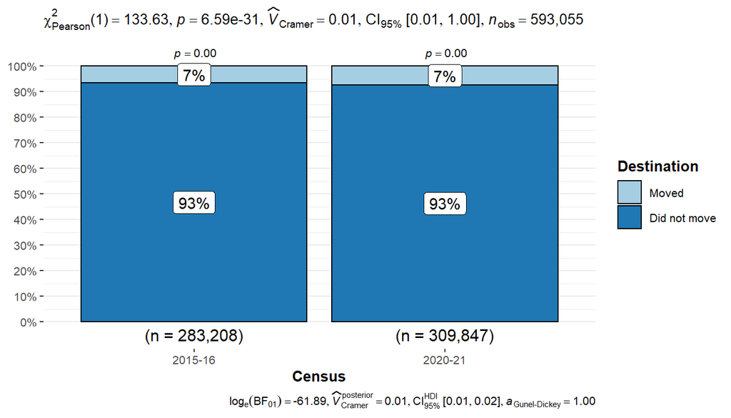

Figure 1: Did or did not move residences in the year prior to the census, inner region (moving to destinations within Australia)

A Person’s chi-squared test indicated that the relationship between which census it was (2016 or 2021) and whether someone living in the inner region one year prior to the census moved was significant $\chi^2(1, N = 593055) = 133.63$, $p < .001$, $\phi = .02$. However, Figure 1 and Table 12 indicate that the actual amount of change in the proportion of people moving was only 0.7% (from 6.6% to 7.3%), and that this change is small compared to the overall number of inner region residents.

Table 13 and Figure 2 looks specifically at those who did move from the inner region within the year before each census. It compares the destinations of people moving away from the inner region of Melbourne to other places in Australia in the year prior to the 2016 and 2021 censuses.

Those moving overseas not included as they are not counted in the census. Those moving to ‘Other Territories’ of Australia are also not included as there are less than 5.

Table 13: Destinations of those moving FROM the Inner region tolocations within Australia in the year prior to the census (excludingother territories)

| Destination | 2015-16 | 2020-21 |
| --- | --- | --- |
| Inner | 367 (2.0%) | 544 (2.4%) |
| Middle | 1,206 (6.5%) | 1,638 (7.2%) |
| Outer | 10,166 (54.8%) | 10,226 (45.1%) |
| Peri-Urban Areas | 1,634 (8.8%) | 1,842 (8.1%) |
| Rest of Victoria | 765 (4.1%) | 922 (4.1%) |
| New South Wales | 1,942 (10.5%) | 2,558 (11.3%) |
| Queensland | 1,115 (6.0%) | 2,393 (10.6%) |
| South Australia | 259 (1.4%) | 601 (2.7%) |
| Tasmania | 209 (1.1%) | 984 (4.3%) |
| Western Australia | 525 (2.8%) | 385 (1.7%) |
| Northern Territory | 127 (0.7%) | 211 (0.9%) |
| Australian Capital Territory | 241 (1.3%) | 369 (1.6%) |
| Total | 18,556 (100.0%) | 22,673 (100.0%) |

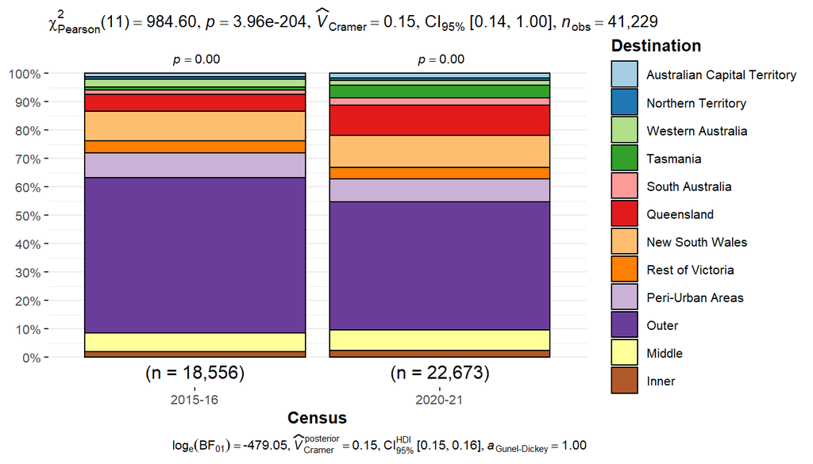

Figure 2: Residential relocation from the inner reigion in the year prior to the census, by destination

A Person’s chi-squared test indicated that the relationship between which census it was (2016 or 2021) and where someone who moved from the inner region in the year prior to the census moved to was significant $\chi^2(11, N = 41229) = 984.60$, $p < .001$. Figure 2 and Table 13 indicate that:

- In 2015-16 54.8% of inner Melbourne residents who moved, moved to the outer region, compared to just 45.1% in 2020-21,
- In 2015-16, 6% of inner Melbourne residents who moved, moved to Queensland, whereas in 2020-21 this proportion had almost double to 11%.

This suggests that there is less movement from the inner to outer regions of Melbounre than before COVID, and more movement to Queensland.

### 4.1.2 FROM the middle region of Melbourne

The fourth columns of Tables 7-10 provide details of where people who where living in the middle region of Melbourne one and five years before the 2016 and 2021 had moved to by 2016 and 2021, respectively. The second column, second row of each table shows the number of people who were living in the middle region and who did not move. Table 14 collects this data.

i.e. in 2011, 2015, 2016 and 2020

Table 14: Destinations of those moving FROM the Middle regionto locations within Victoria prior to the census

| Destination | 2011-16 | 2015-16 | 2016-21 | 2020-21 |
| --- | --- | --- | --- | --- |
| Did not move | 1,091,546 (76.7%) | 1,605,376 (92.3%) | 1,172,227 (75.0%) | 1,748,083 (91.8%) |
| Inner | 10,736 (0.8%) | 4,379 (0.3%) | 12,261 (0.8%) | 7,347 (0.4%) |
| Middle | 76,908 (5.4%) | 33,254 (1.9%) | 85,504 (5.5%) | 37,938 (2.0%) |
| Outer | 142,917 (10.0%) | 55,710 (3.2%) | 168,927 (10.8%) | 63,157 (3.3%) |
| Peri-Urban Areas | 76,999 (5.4%) | 30,981 (1.8%) | 95,281 (6.1%) | 38,090 (2.0%) |
| Rest of Victoria | 24,516 (1.7%) | 9,732 (0.6%) | 28,135 (1.8%) | 10,500 (0.6%) |
| Total | 1,423,622 (100.0%) | 1,739,432 (100.0%) | 1,562,335 (100.0%) | 1,905,115 (100.0%) |

However, the ‘Rest of Australia’ data needs to be added as well, so that it is possible to see people who moved from middle to other parts of Australia. This revision is shown in Table 15.

This was imported from the ABS data above, see Table 5

Table 15: Destinations of those moving FROM the middle regionto locations within Australia prior to the census

| Destination | 2015-16 | 2020-21 | 2011-16 | 2016-21 |
| --- | --- | --- | --- | --- |
| Did not move | 1,605,376 (91.5%) | 1,748,083 (90.5%) | 1,091,546 (74.5%) | 1,172,227 (72.5%) |
| Inner | 4,379 (0.2%) | 7,347 (0.4%) | 10,736 (0.7%) | 12,261 (0.8%) |
| Middle | 33,254 (1.9%) | 37,938 (2.0%) | 76,908 (5.3%) | 85,504 (5.3%) |
| Outer | 55,710 (3.2%) | 63,157 (3.3%) | 142,917 (9.8%) | 168,927 (10.4%) |
| Peri-Urban Areas | 30,981 (1.8%) | 38,090 (2.0%) | 76,999 (5.3%) | 95,281 (5.9%) |
| Rest of Victoria | 9,732 (0.6%) | 10,500 (0.5%) | 24,516 (1.7%) | 28,135 (1.7%) |
| New South Wales | 5,213 (0.3%) | 7,258 (0.4%) | 13,733 (0.9%) | 16,399 (1.0%) |
| Queensland | 4,332 (0.2%) | 8,171 (0.4%) | 11,798 (0.8%) | 17,623 (1.1%) |
| South Australia | 1,270 (0.1%) | 2,867 (0.1%) | 3,642 (0.2%) | 5,242 (0.3%) |
| Tasmania | 902 (0.1%) | 2,775 (0.1%) | 1,964 (0.1%) | 5,157 (0.3%) |
| Western Australia | 1,382 (0.1%) | 2,065 (0.1%) | 5,598 (0.4%) | 5,052 (0.3%) |
| Northern Territory | 497 (0.0%) | 933 (0.0%) | 1,265 (0.1%) | 1,924 (0.1%) |
| Australian Capital Territory | 1,022 (0.1%) | 1,917 (0.1%) | 2,661 (0.2%) | 3,873 (0.2%) |
| Other Territories | 4 (0.0%) | 8 (0.0%) | 6 (0.0%) | 12 (0.0%) |
| Total | 1,754,054 (100.0%) | 1,931,109 (100.0%) | 1,464,289 (100.0%) | 1,617,617 (100.0%) |

Figure 3 and Table 16 compare the proportion of those who were middle region residents one year prior to each census who moved within Australia in the year before each census.

People who moved overseas are not included as they are not present in the census data

Table 16: Middle region residents one year prior to the census,residential relocation in the year prior to the census, bycensus

| Destination | 2015-16 | 2020-21 |
| --- | --- | --- |
| Did not move | 1,605,376 (91.5%) | 1,748,083 (90.5%) |
| Moved | 148,678 (8.5%) | 183,026 (9.5%) |
| Total | 1,754,054 (100.0%) | 1,931,109 (100.0%) |

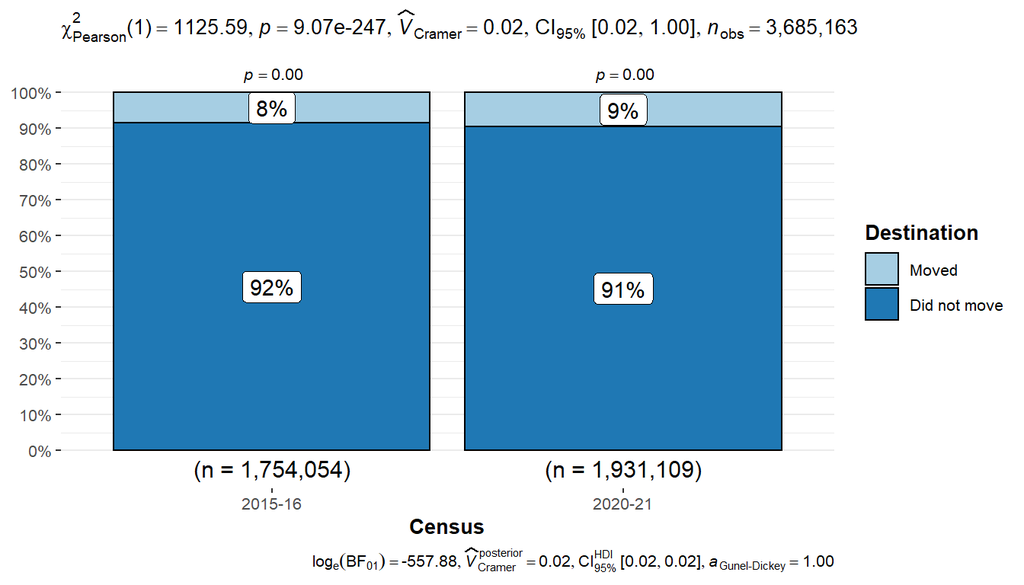

Figure 3: Did or did not move residences in the year prior to the census, middle region (moving to destinations within Australia)

Table 17 and Figure 4 looks specifically at those who did move from the middle region within the year before each census. It compares the destinations of people moving away from the middle region of Melbourne to other places in Australia in the year prior to the 2016 and 2021 censuses.

And again, does not include those who moved overseas as they are not included in the census. Those moving to ‘Other territories’ are also excluded, as there were very few of them

Table 17: Destinations of those moving FROM the middle regionto locations within Australia in the year prior to the census (excludingother territories)

| Destination | 2015-16 | 2020-21 |
| --- | --- | --- |
| Inner | 4,379 (2.9%) | 7,347 (4.0%) |
| Middle | 33,254 (22.4%) | 37,938 (20.7%) |
| Outer | 55,710 (37.5%) | 63,157 (34.5%) |
| Peri-Urban Areas | 30,981 (20.8%) | 38,090 (20.8%) |
| Rest of Victoria | 9,732 (6.5%) | 10,500 (5.7%) |
| New South Wales | 5,213 (3.5%) | 7,258 (4.0%) |
| Queensland | 4,332 (2.9%) | 8,171 (4.5%) |
| South Australia | 1,270 (0.9%) | 2,867 (1.6%) |
| Tasmania | 902 (0.6%) | 2,775 (1.5%) |
| Western Australia | 1,382 (0.9%) | 2,065 (1.1%) |
| Northern Territory | 497 (0.3%) | 933 (0.5%) |
| Australian Capital Territory | 1,022 (0.7%) | 1,917 (1.0%) |
| Total | 148,674 (100.0%) | 183,018 (100.0%) |

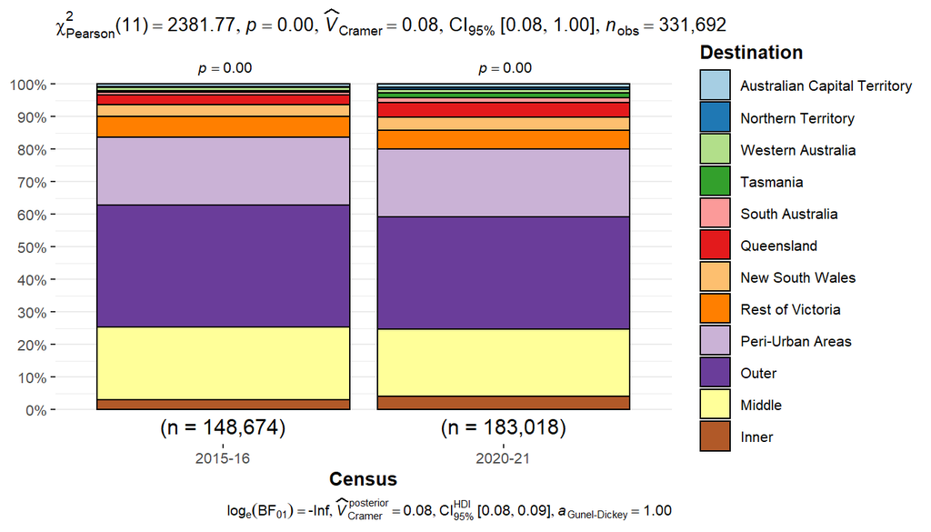

Figure 4: Residential relocation from the middle reigion in the year prior to the census, by destination

A Person’s chi-squared test indicated that the relationship between which census it was (2016 or 2021) and where someone who moved from the middle region in the year prior to the census was significant $\chi^2(11, N = 331692) = 2381.77$, $p < .001$. Figure 4 and Table 17 indicate that:

- In 2015-16, 37.5% of middle Melbourne residents who moved, moved to the outer region, compared to just 34.5%% in 2020-21,
- Of middle residents who moved, the proportions who moved to the inner region (2.9% to 4.0%), Queensland (2.9% to 4.5%) and Tasmania (0.6% to 1.5%) all increased by relatively small amounts between 2015-16 and 2020-21.

This suggests that there was proportionally less movement from the middle to outer regions of Melbourne than before COVID, and proportionally more movement to the inner region, Queensland and Tasmania.

### 4.1.3 FROM the outer region of Melbourne

The fifth columns of Tables 7-10 provide details of where people who where living in the outer region of Melbourne one and five years before the 2016 and 2021 had moved to by 2016 and 2021, respectively. The second column, third row of each table shows the number of people who were living in the outer region and who did not move. Table 18 collects this data.

i.e. in 2011, 2015, 2016 and 2020

Table 18: Destinations of those moving FROM the Outer region tolocations within Victoria prior to the census

| Destination | 2011-16 | 2015-16 | 2016-21 | 2020-21 |
| --- | --- | --- | --- | --- |
| Did not move | 985,787 (89.0%) | 1,496,836 (95.8%) | 1,141,599 (88.3%) | 1,819,216 (95.7%) |
| Inner | 26,837 (2.4%) | 23,344 (1.5%) | 37,706 (2.9%) | 37,043 (1.9%) |
| Middle | 29,615 (2.7%) | 15,336 (1.0%) | 37,323 (2.9%) | 16,831 (0.9%) |
| Outer | 9,195 (0.8%) | 3,649 (0.2%) | 13,891 (1.1%) | 5,315 (0.3%) |
| Peri-Urban Areas | 13,027 (1.2%) | 4,701 (0.3%) | 16,147 (1.2%) | 5,441 (0.3%) |
| Rest of Victoria | 43,030 (3.9%) | 17,879 (1.1%) | 45,682 (3.5%) | 17,770 (0.9%) |
| Total | 1,107,491 (100.0%) | 1,561,745 (100.0%) | 1,292,348 (100.0%) | 1,901,616 (100.0%) |

However, the ‘Rest of Australia’ data needs to be added as well, so that it is possible to see people who moved from outer Melbourne to other parts of Australia. This revision is shown in Table 19.

This was imported from the ABS data above, see Table 5

Table 19: Destinations of those moving FROM the Outer region tolocations within Australia prior to the census

| Destination | 2015-16 | 2020-21 | 2011-16 | 2016-21 |
| --- | --- | --- | --- | --- |
| Did not move | 1,496,836 (95.1%) | 1,819,216 (94.6%) | 985,787 (86.4%) | 1,141,599 (85.3%) |
| Inner | 23,344 (1.5%) | 37,043 (1.9%) | 26,837 (2.4%) | 37,706 (2.8%) |
| Middle | 15,336 (1.0%) | 16,831 (0.9%) | 29,615 (2.6%) | 37,323 (2.8%) |
| Outer | 3,649 (0.2%) | 5,315 (0.3%) | 9,195 (0.8%) | 13,891 (1.0%) |
| Peri-Urban Areas | 4,701 (0.3%) | 5,441 (0.3%) | 13,027 (1.1%) | 16,147 (1.2%) |
| Rest of Victoria | 17,879 (1.1%) | 17,770 (0.9%) | 43,030 (3.8%) | 45,682 (3.4%) |
| New South Wales | 3,560 (0.2%) | 5,164 (0.3%) | 9,284 (0.8%) | 11,625 (0.9%) |
| Queensland | 4,315 (0.3%) | 8,049 (0.4%) | 12,671 (1.1%) | 19,698 (1.5%) |
| South Australia | 809 (0.1%) | 1,997 (0.1%) | 2,268 (0.2%) | 3,573 (0.3%) |
| Tasmania | 603 (0.0%) | 2,360 (0.1%) | 1,561 (0.1%) | 4,463 (0.3%) |
| Western Australia | 1,349 (0.1%) | 1,356 (0.1%) | 4,515 (0.4%) | 3,033 (0.2%) |
| Northern Territory | 503 (0.0%) | 808 (0.0%) | 1,274 (0.1%) | 1,506 (0.1%) |
| Australian Capital Territory | 536 (0.0%) | 920 (0.0%) | 1,352 (0.1%) | 1,882 (0.1%) |
| Other Territories | 4 (0.0%) | 3 (0.0%) | 7 (0.0%) | 15 (0.0%) |
| Total | 1,573,424 (100.0%) | 1,922,273 (100.0%) | 1,140,423 (100.0%) | 1,338,143 (100.0%) |

Figure 5 and Table 19 compare the proportion of those who were outer region residents one year prior to each census who moved within Australia in the year before each census.

People who moved overseas are not included as they are not present in the census data

Table 19: Outer region residents one year prior to the census,residential relocation in the year prior to the census, bycensus

| Destination | 2015-16 | 2020-21 |
| --- | --- | --- |
| Did not move | 1,496,836 (95.1%) | 1,819,216 (94.6%) |
| Moved | 76,588 (4.9%) | 103,057 (5.4%) |
| Total | 1,573,424 (100.0%) | 1,922,273 (100.0%) |

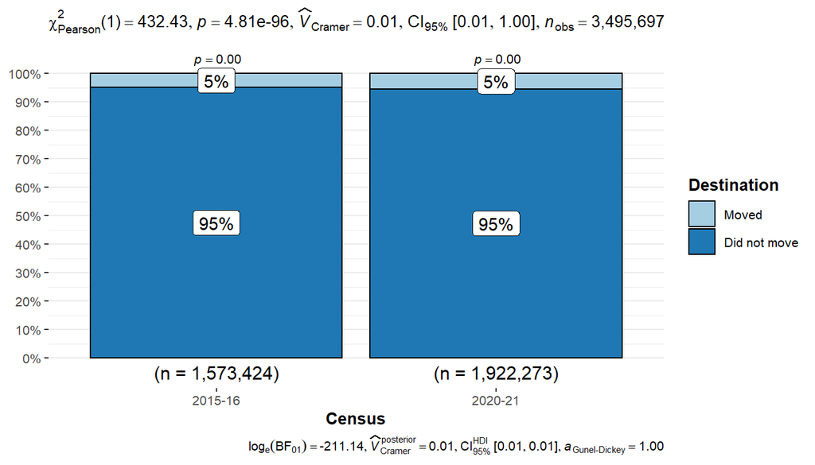

Figure 5: Did or did not move residences in the year prior to the census, outer region (moving to destinations within Australia)

A Person’s chi-squared test indicated that the relationship between which census it was (2016 or 2021) and whether someone living in the outer region one year prior to the census moved was significant $\chi^2(1, N = 3495697) = 432.43$, $p < .001$, $\phi = .01$. However, Figure 5 and Table 19 indicate that the actual amount of change in the proportion of people moving was less than 1.0% (from 4.9% to 5.4%), and that this change is small compared to the overall number of outer region residents.

Table 20 and Figure 6 looks specifically at those who did move from the outer region within the year before each census. It compares the destinations of people moving away from the outer region of Melbourne to other places in Australia in the year prior to the 2016 and 2021 censuses.

And again, does not include those who moved overseas as they are not included in the census. Those moving to ‘Other territories’ are also excluded, as there were very few of them

Table 20: Destinations of those moving FROM the outer region tolocations within Australia in the year prior to the census (excludingother territories)

| Destination | 2015-16 | 2020-21 |
| --- | --- | --- |
| Inner | 23,344 (30.5%) | 37,043 (35.9%) |
| Middle | 15,336 (20.0%) | 16,831 (16.3%) |
| Outer | 3,649 (4.8%) | 5,315 (5.2%) |
| Peri-Urban Areas | 4,701 (6.1%) | 5,441 (5.3%) |
| Rest of Victoria | 17,879 (23.3%) | 17,770 (17.2%) |
| New South Wales | 3,560 (4.6%) | 5,164 (5.0%) |
| Queensland | 4,315 (5.6%) | 8,049 (7.8%) |
| South Australia | 809 (1.1%) | 1,997 (1.9%) |
| Tasmania | 603 (0.8%) | 2,360 (2.3%) |
| Western Australia | 1,349 (1.8%) | 1,356 (1.3%) |
| Northern Territory | 503 (0.7%) | 808 (0.8%) |
| Australian Capital Territory | 536 (0.7%) | 920 (0.9%) |
| Total | 76,584 (100.0%) | 103,054 (100.0%) |

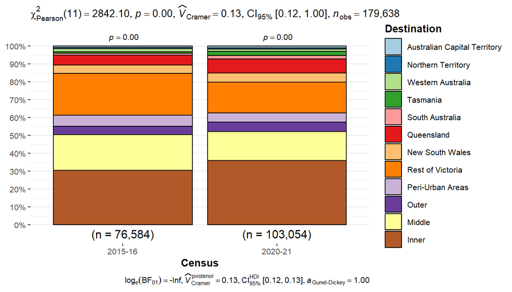

Figure 6: Residential relocation from the outer reigion in the year prior to the census, by destination

A Person’s chi-squared test indicated that the relationship between which census it was (2016 or 2021) and where someone who moved from the outer region in the year prior to the census moved to was significant $\chi^2(11, N = 179638) = 2842.10$, $p < .001$. Figure 6 and Table 20 indicate that:

- In 2015-16 30.5% of outer Melbourne residents who moved, moved to the inner region, but this increased to 35.9% in 2020-21,
- There were also increases in the proportion of outer Melbourne residents who moved who moved to Queensland (5.6% to 7.8%) and Tasmania (0.8% to 2.3%),
- In 2015-16 20.0%of outer Melbourne residents who moved, moved to the middle region of Melbourne, but this fell to only 16.3% in 2020-21,
- There were also falls in the proportion of outer Melbourne residents who moved who moved to the rest of Victoria (23.3% to 17.2%).

This suggests that those who were relocating from the outer surburbs of Melbourne after the start of COVID-19 were more likely to be moving to the inner parts of Melbourne and Queensland, and less likely to be moving to the middle suburbs and the rest of Victoria.